# **Deep Learning Project, ST2NL2**

After each epoch, we print the Loss_D and Loss_G and show 9 generated images to track how it's improving visually.

```
[Epoch 1/20] Loss_D: 0.8787 | Loss_G: 7.8032
```

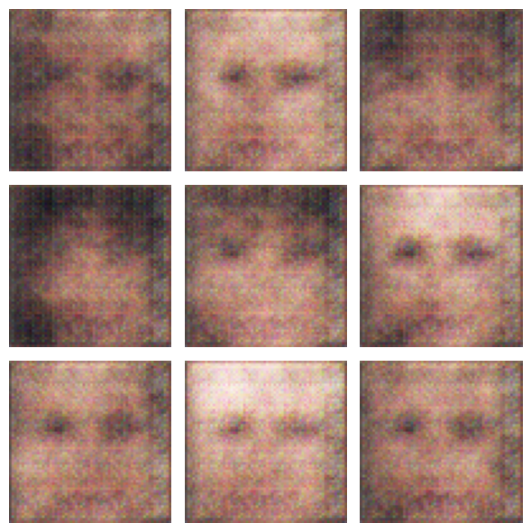

```
[Epoch 2/20] Loss_D: 0.7605 | Loss_G: 5.0960
```

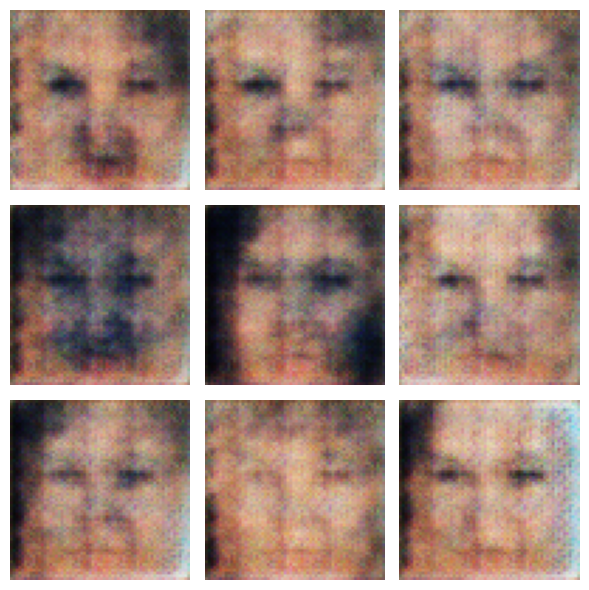

```
[Epoch 3/20] Loss_D: 0.7473 | Loss_G: 4.3074
```

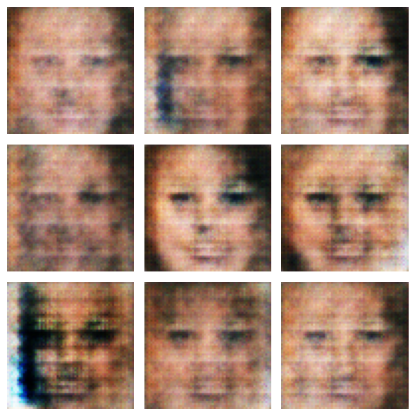

```
[Epoch 4/20] Loss_D: 0.8011 | Loss_G: 4.2182
```

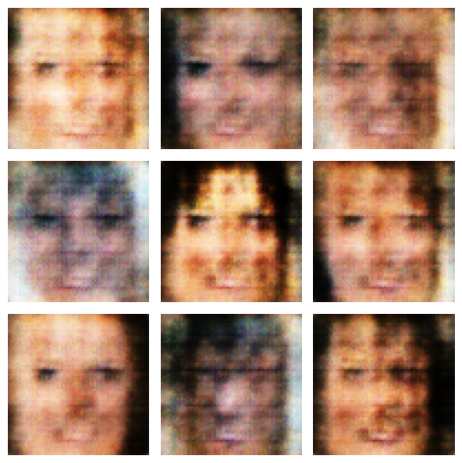

```
[Epoch 5/20] Loss_D: 0.8143 | Loss_G: 4.2552
```

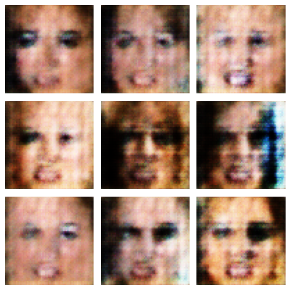

```
[Epoch 6/20] Loss_D: 0.7960 | Loss_G: 4.0861
```

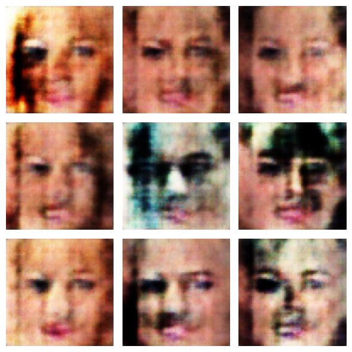

```
[Epoch 7/20] Loss_D: 0.7934 | Loss_G: 3.9059
```

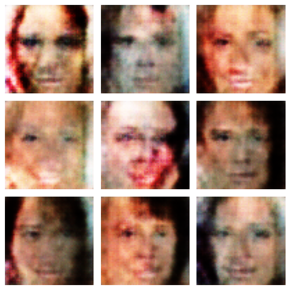

```
[Epoch 8/20] Loss_D: 0.7962 | Loss_G: 3.4823
```

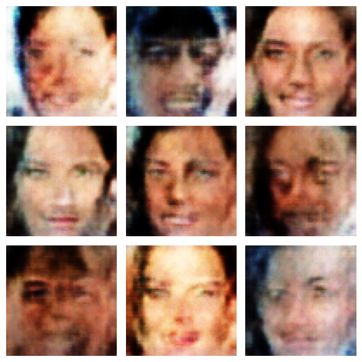

```
[Epoch 9/20] Loss_D: 0.8596 | Loss_G: 3.1235
```

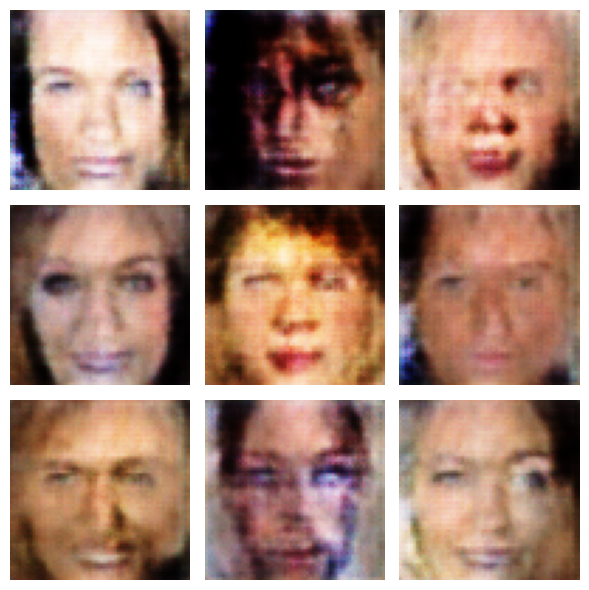

```
[Epoch 10/20] Loss_D: 0.8034 | Loss_G: 2.9422
```

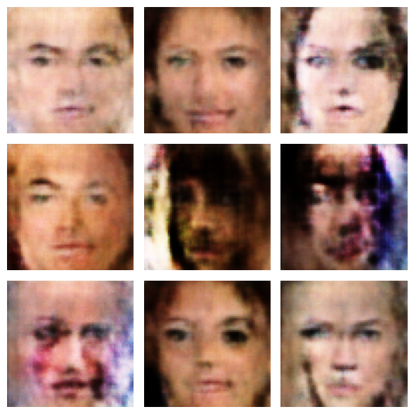

```
[Epoch 11/20] Loss_D: 0.8262 | Loss_G: 2.9926
```

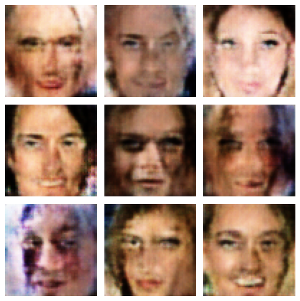

```
[Epoch 12/20] Loss_D: 0.8921 | Loss_G: 2.9127
```

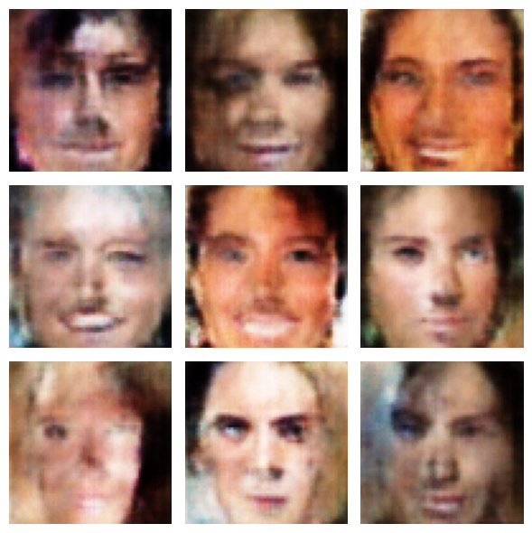

```
[Epoch 13/20] Loss_D: 0.8051 | Loss_G: 2.8754
```

[8 more figures not shown]

```python
for epoch in range(epochs):
    loss_G_epoch = 0
    loss_D_epoch = 0

    for real_imgs, _ in tqdm(trainloader, desc=f"Epoch {epoch+1}/{epochs}"):
        real_imgs = real_imgs.to(device)
        b_size = real_imgs.size(0)

        # --- Train D ---
        D.zero_grad()
        real_labels = torch.full((b_size, 1), 0.9, device=device)
        fake_labels = torch.zeros(b_size, 1, device=device)

        output_real = D(real_imgs)
        loss_real = criterion(output_real, real_labels)

        z = torch.randn(b_size, z_dim, 1, 1, device=device)
        fake_imgs = G(z)
        output_fake = D(fake_imgs.detach())
        loss_fake = criterion(output_fake, fake_labels)

        loss_D = loss_real + loss_fake
        loss_D.backward()
        optimizer_D.step()

        # --- Train G ---
        G.zero_grad()
        output_fake = D(fake_imgs)
        loss_G = criterion(output_fake, real_labels)
        loss_G.backward()
        optimizer_G.step()

        loss_G_epoch += loss_G.item()
        loss_D_epoch += loss_D.item()


    print(f"\n[Epoch {epoch+1}/{epochs}] Loss_D: {loss_D_epoch/len(trainloader):.4f} | Loss_G: {loss_G_epoch/len(trainloader):.4f}")

    # Visualization
    with torch.no_grad():
        z = torch.randn(9, z_dim, 1, 1).to(device)
        gen_imgs = G(z).cpu()
        fig, axes = plt.subplots(3, 3, figsize=(6, 6))
        for i, ax in enumerate(axes.flatten()):
            img = gen_imgs[i].permute(1, 2, 0).numpy()
            img = (img + 1) / 2
            ax.imshow(img)
            ax.axis("off")
        plt.tight_layout()
        plt.show()
```

At the first epoch, the images are just blurry blobs. The Generator is still learning. The Loss_G is around 7.8 which is high, and the Discriminator is already doing well with a Loss_D nearly equal to 0.88 but not perfect.

From epoch 4 to 8, faces become more detailed, with more realistic shapes and textures, even if some are still distorted.

At the end of epoch 19 and 20, most images look realistic. We can clearly see smiles, eyes, skin tones, and even facial expressions. Some faces are really clean. Other images still have some issues but the general progress of the Generator is good. The Generator loss goes down to nearly 2.7, and the Discriminator stays around 0.8, showing a good balance.

In short, the training works well. The two losses evolve properly and the image quality improves a lot at each epoch during trainiong. The GAN is good, the Generator successfully learns to create realistic face images over time and the Discriminator manage well to distinguish the fake faces from the true faces.

### **Convert notebook to html**

```python
!jupyter nbconvert --to html 'Deep_Learning_Project_Marion_FRESQUET_Manel_EL_KOUCH_ING2_BIOINF.ipynb.ipynb'
```

[output not shown]

[output cut: 133 more lines]

[output not shown]